# NHANES Equity Summary

# Report Template: NHANES Equity Summary

## Purpose

This runnable template shows how to pair a dashboard with a short reproducible report. The dashboard supports exploration; the report fixes one question, documents the data, and cites the source.

## Question

How does mean BMI vary by income group among adults age 20-80 in the prepared NHANES Health Equity classroom dataset?

## Data Source

The report uses the cached CSV snapshot at `examples/nhanes-equity/data/nhanes_equity_v6.csv`. The source data are derived from CDC/NCHS NHANES public-use files (Centers for Disease Control and Prevention, National Center for Health Statistics 2026).

```r
library(tidyverse)  # AI-EDIT(2026-06-23): tidyverse-default — consolidated core library() calls into library(tidyverse)
library(knitr)

candidate_paths <- c(
  "examples/nhanes-equity/data/nhanes_equity_v6.csv",
  "../../examples/nhanes-equity/data/nhanes_equity_v6.csv"
)

data_path <- candidate_paths[file.exists(candidate_paths)][1]
if (is.na(data_path)) {
  stop("Could not find examples/nhanes-equity/data/nhanes_equity_v6.csv")
}

nhanes <- read_csv(data_path, show_col_types = FALSE)
```

## Methods

We restricted the classroom dataset to adults age 20-80 and summarized BMI by income group. The summaries are unweighted and descriptive. They should not be interpreted as causal effects or national population estimates.

```r
analysis_df <- nhanes |>
  filter(Age >= 20, Age <= 80)

missingness <- analysis_df |>
  summarise(
    rows = n(),
    missing_bmi = sum(is.na(BMI)),
    missing_income = sum(is.na(IncomeGroup)),
    missing_age = sum(is.na(Age))
  )

kable(missingness, caption = "Missingness check for key report variables.")
```

Missingness check for key report variables.

| rows | missing_bmi | missing_income | missing_age |
| --- | --- | --- | --- |
| 57137 | 1009 | 5395 | 0 |

## Results

```r
income_summary <- analysis_df |>
  filter(!is.na(BMI), !is.na(IncomeGroup)) |>
  group_by(IncomeGroup) |>
  summarise(
    n = n(),
    mean_bmi = mean(BMI),
    sd_bmi = sd(BMI),
    .groups = "drop"
  ) |>
  mutate(
    `BMI, mean (SD)` = sprintf("%.1f (%.1f)", mean_bmi, sd_bmi)
  ) |>
  select(IncomeGroup, n, `BMI, mean (SD)`)

kable(income_summary, caption = "Descriptive BMI summary by income group.")
```

Descriptive BMI summary by income group.

| IncomeGroup | n | BMI, mean (SD) |
| --- | --- | --- |
| High Income (>3.5) | 16330 | 28.6 (6.3) |
| Low Income (<1.3) | 15293 | 29.4 (7.5) |
| Middle Income | 19228 | 29.3 (7.0) |

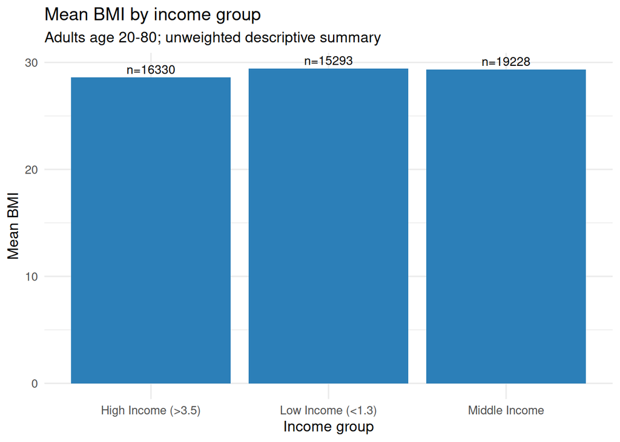

Mean BMI by income group among adults age 20-80 in the prepared NHANES Health Equity classroom dataset. Values are unweighted and descriptive.

```r
plot_df <- analysis_df |>
  filter(!is.na(BMI), !is.na(IncomeGroup)) |>
  group_by(IncomeGroup) |>
  summarise(
    n = n(),
    mean_bmi = mean(BMI),
    .groups = "drop"
  )

ggplot(plot_df, aes(x = IncomeGroup, y = mean_bmi)) +
  geom_col(fill = "#2C7FB8") +
  geom_text(aes(label = paste0("n=", n)), vjust = -0.4, size = 3.5) +
  labs(
    title = "Mean BMI by income group",
    subtitle = "Adults age 20-80; unweighted descriptive summary",
    x = "Income group",
    y = "Mean BMI"
  ) +
  expand_limits(y = 0) +
  theme_minimal(base_size = 12)
```

## Limitations

- The table and figure use a prepared classroom dataset rather than raw NHANES files.
- The summaries are unweighted.
- The comparison is descriptive and does not establish causality.
- Missing BMI or income group values are excluded from the grouped summary.

## Plain-Language Summary

In this classroom dataset, mean BMI differs across income groups. The result is useful for practicing reproducible reporting and dashboard interpretation, but it should be described as a descriptive pattern rather than a causal finding.

## AI-Use and Audit Note

- prompt: help me revise the whole qmd file given the checklist: ” - Report renders from source. - Citations resolve. - Figures and tables are generated by code. - Private preview is used unless the data, repository, and group privacy checks support public sharing. - Public preview contains no restricted data, private links, credentials, or sensitive row-level examples. - Staged files were reviewed before committing: no raw row-level data, credentials, `.RData` workspaces, or unrelated generated files. The required `report.html` remains staged with its source. - Private repository access is granted to course staff when needed. - Canvas submission includes the repository link, report path, and latest commit hash.” - result: the Private Preview and Sharing is not sufficient, need to add things checked for the previoew

# Private Preview and Sharing

A private preview will be used unless checks of the data, repository contents, and any applicable group privacy requirements support public sharing. Before publishing, I will check that the preview contains no restricted data, private links, credentials, or sensitive row-level examples.

## Publishing Checklist

- Report renders from source.
- Citations resolve.
- Figures and tables are generated by code.
- Private preview is used unless the data, repository, and group privacy checks support public sharing.
- Public preview contains no restricted data, private links, credentials, or sensitive row-level examples.
- Staged files were reviewed before committing: no raw row-level data, credentials, `.RData` workspaces, or unrelated generated files. The required `report.html` remains staged with its source.
- Private repository access is granted to course staff when needed.
- Canvas submission includes the repository link, report path, and latest commit hash.

## Grounding Audit Prompt

Select three claims from the report. For each claim, write the supporting evidence source: code chunk, table, figure, or citation. Revise any claim that cannot be traced to evidence in the report.

## claim 1:

income information was missing more frequently than BMI in the collected data. - evidence: The “Missingness check for key report variables” table shows 5,395 missing income values compared with 1,009 missing BMI values among 57,137 records. -

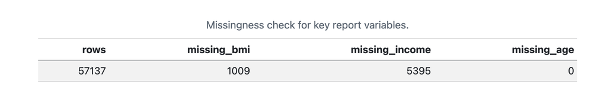

## claim 2:

Among adults aged 20–80 in the prepared dataset, the high-income group had a lower mean BMI than the low- and middle-income groups. - evidence: Mean BMI was 28.6 for the high-income group, compared with 29.4 for the low-income group and 29.3 for the middle-income group. -

## claim 3:

The low- and middle-income groups had very similar mean BMI values. - Evidence: Their reported means differed by approximately 0.1 BMI units, compared with a difference of approximately 0.8 units between the low- and high-income groups. -

## References

Centers for Disease Control and Prevention, National Center for Health Statistics. 2026. *National Health and Nutrition Examination Survey*. https://wwwn.cdc.gov/nchs/nhanes/.